# Modeling (Logistic Regression)

### Results (Precision)

We see a fairly similar patternw hen looking at precision (percent correct when making a prediction that a statement is a truth). Performance increases with more training data, but with diminishing returns (and the top 100 words appear to be the most useful features). (Negative predictive value results are not shown next, as at this point in time in the analysis, I was not focusing on that metric, and indeed did not even save it when storing the results of the models.)

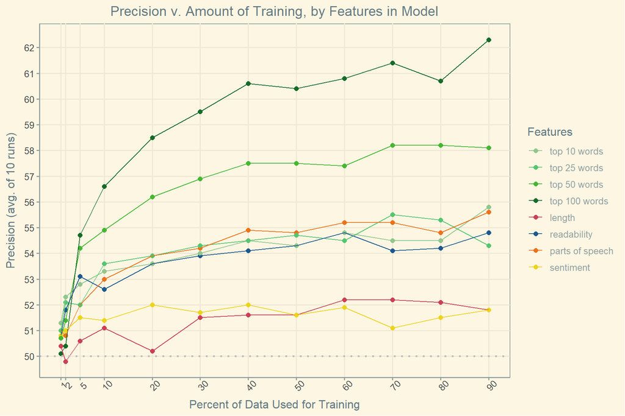

```r
# print plot
ggplot(data = results_summ,
       aes(x = round(split * 100, 1),
           y = round(avg_precision * 100, 1),
           color = feature_set)) +
  geom_point(size = 2) +
  geom_line(size = 0.5) +
  # geom_errorbar(aes(ymin = round(min_precision * 100, 1),
  #                 ymax = round(max_precision * 100, 1)),
  #               alpha = 0.5,
  #               width = 0) +
  geom_hline(yintercept = 50,
             color = "grey",
             linetype = "dotted",
             size = 1) +
  scale_x_continuous(breaks = (split_probs * 100)) +
  scale_y_continuous(breaks = seq(from = 40, to = 70, by = 1)) +
  scale_color_manual(values = color_map) +
  labs(x = "Percent of Data Used for Training",
       y = "Precision (avg. of 10 runs)",
       title = "Precision v. Amount of Training, by Features in Model",
       color = "Features") +
  theme_solarized() +
  theme(plot.title = element_text(hjust = 0.5),
        axis.text.x = element_text(angle = 45),
        panel.grid.minor = element_blank(),
        legend.key = element_rect(color = "transparent", fill = "transparent"),
        axis.title.y = element_text(margin = margin(t = 0, r = 8, b = 0, l = 0)))
```

## Save Additional Results

Here I am saving the results from the additional analyses conducted above.

```r
# DO NOT RUN THIS (correct results already saved month ago; don't risk over-riding with wrong data)
# this is left here for legacy reasons (to remind name of output file, and sequence of analysis)

# save(results,
#     file = "log_results1.Rda")
```

# Render

Again, some chunks which take long to evaluate are not evaluating and instead saved/loaded from current directory. Rendering with: rmarkdown::render(“hld_MODEL_logistic.Rmd”)

# Citations

- Binomial proportion confidence interval. (2019). In Wikipedia. Retrieved from https://en.wikipedia.org/w/index.php?title=Binomial_proportion_confidence_interval&oldid=895045323
- Gelman, A., & Hill, J. (2006). Data analysis using regression and multilevel/hierarchical models. Cambridge university press.
- Kuhn, M. (2008). Building predictive models in R using the caret package. Journal of Statistical Software, 28(5), 1-26.
- Kuhn, M. (2019). The caret Package. Retrieved from https://topepo.github.io/caret/index.html
- Logistic regression. (2019). In Wikipedia. Retrieved from https://en.wikipedia.org/w/index.php?title=Logistic_regression&oldid=896435137